# Introduction to Biostatistics

# 1 Learning objectives

## 1.1 Learning objectives

- *Describe* the logic of factorial ANOVA
  - Including main effects and interactions
- *Conduct* and *interpret* the factorial ANOVA tests
- *Conduct* post hoc tests for the factorial ANOVA

# 2 Review

## 2.1 One-way ANOVA

- a.k.a. one factor ANOVA, between-subjects ANOVA
- One *factor* (grouping variable) with *independent* groups
  - The **“between-subjects”** factor
- One continuous outcome
- Group differences on the outcome
  - Partitioned variance: Between and within (error)
  - **Ratio** of between-group variance to within-group variance

## 2.2 Post hoc tests

- One-way ANOVA has 3 or more groups
  - Omnibus test: Is at least one mean different?
  - Post hoc tests to determine **which**
  - Contrasts: Dummy (treatment), sum (grand mean), polynomial

# 3 Factorial ANOVA

## 3.1 Factorial ANOVA

- Many names
  - Factorial (not specifying *how many factors*)
  - Two-way between-subjects ANOVA
  - Two-factor between-subjects ANOVA
  - $2 \times 3$ between-subjects ANOVA

## 3.2 Partitioned variance

- Multiple factors = more partitioning
- With 2 factors (and their **interaction**)
  - Between-group variance for *factor A*
  - Between-group variance for *factor B*
  - Between-group variance for the *interaction*
  - *Residual* (within-group) variance

## 3.3 Interactions

- Is the effect of factor A the same *at all levels of factor B*?
  - Likewise, is the effect of factor B the same *at all levels of factor A*?
- **If not, you have an interaction**
  - *Conditional* effects
  - Is there an effect of factor A?
    - It **depends** on the level of factor B

## 3.4 Example: Group, Sex, No interaction

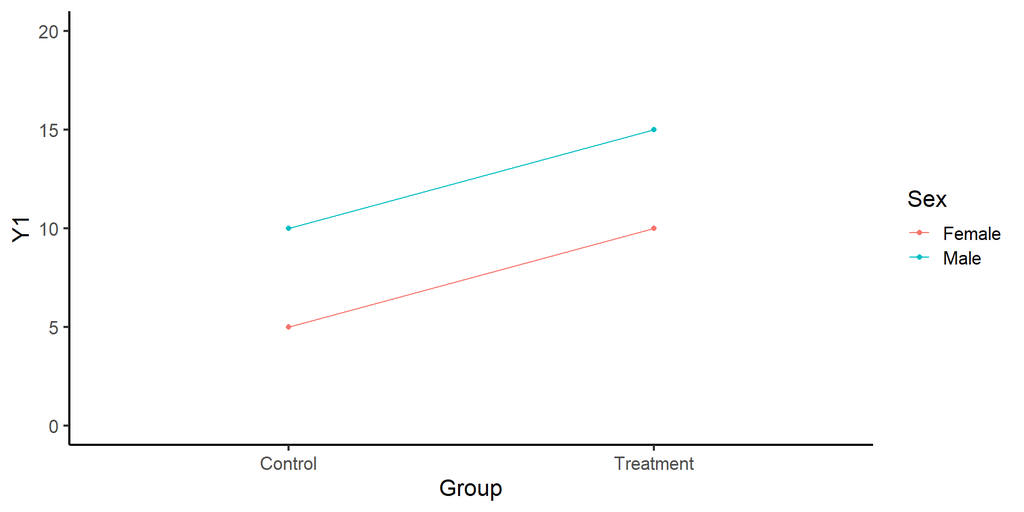

```r
Group <- c("Control", "Treatment", "Control", "Treatment")
Sex <- c("Female", "Female", "Male", "Male")
Y1 <- c(5, 10, 10, 15)
int1 <- data.frame(Group, Sex, Y1)
ggplot(data = int1,
       aes(x = Group,
           y = Y1,
           group = Sex,
           color = Sex)) +
  geom_point() +
  geom_path(aes(group = Sex)) +
  ylim(0,20)
```

## 3.5 Example: Group, No Sex, No interaction

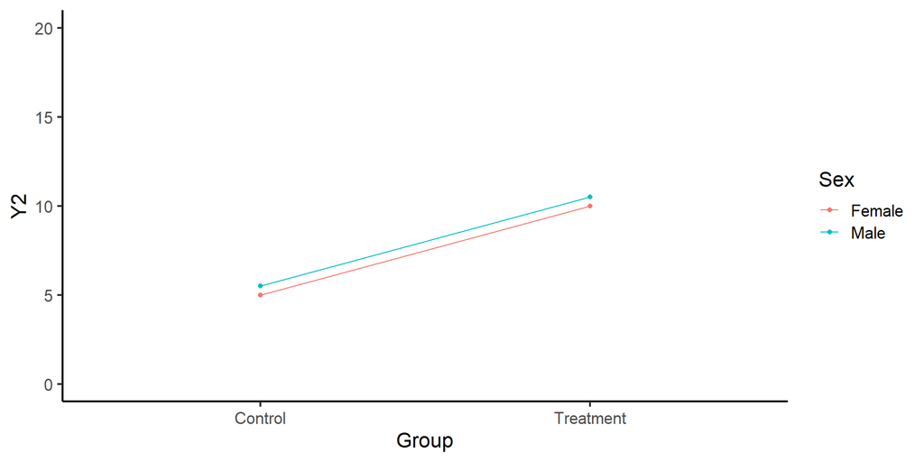

```r
Y2 <- c(5, 10, 5.5, 10.5)
int2 <- data.frame(Group, Sex, Y2)
ggplot(data = int2,
       aes(x = Group,
           y = Y2,
           group = Sex,
           color = Sex)) +
  geom_point() +
  geom_path(aes(group = Sex)) +
  ylim(0,20)
```

## 3.6 Example: No Group, Sex, No interaction

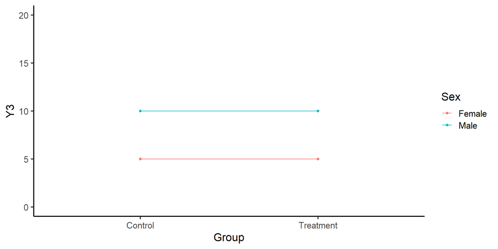

```r
Y3 <- c(5, 5, 10, 10)
int3 <- data.frame(Group, Sex, Y3)
ggplot(data = int3,
       aes(x = Group,
           y = Y3,
           group = Sex,
           color = Sex)) +
  geom_point() +
  geom_path(aes(group = Sex)) +
  ylim(0,20)
```

## 3.7 Example: Group, Sex, interaction (!!!)

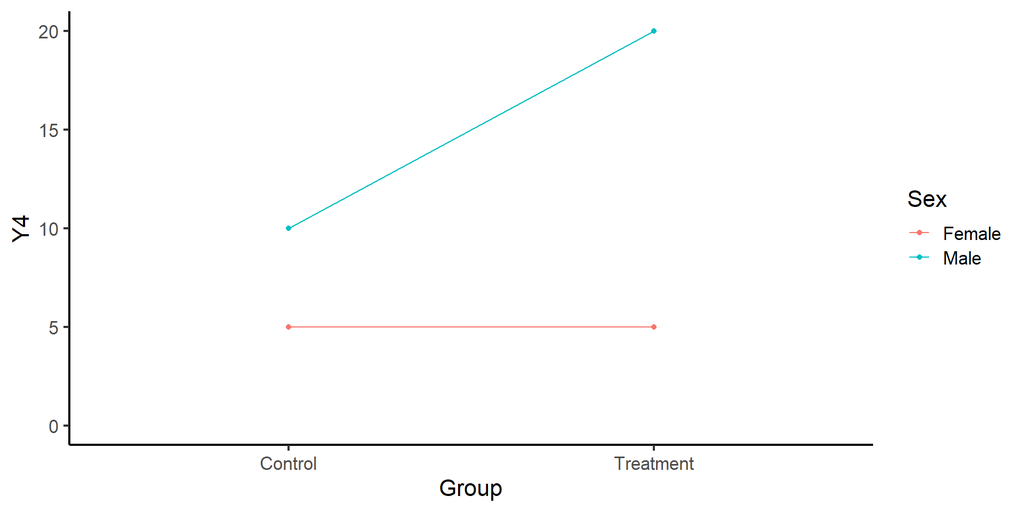

```r
Y4 <- c(5, 5, 10, 20)
int4 <- data.frame(Group, Sex, Y4)
ggplot(data = int4,
       aes(x = Group,
           y = Y4,
           group = Sex,
           color = Sex)) +
  geom_point() +
  geom_path(aes(group = Sex)) +
  ylim(0,20)
```

## 3.8 Which means for which effects?

- **Main effect** of factor A
  - Means for factor A, *ignoring factor B*
- **Main effect** of factor B
  - Means for factor B, *ignoring factor A*
- Effect of interaction
  - Means of all combinations (means in plots)
- Parallels to contingency tables: **marginal values (factors)** and **joint values (interaction)**

## 3.9 Assumptions

- **Two** *categorical* (grouping) variables with 2+ categories
- One *continuous* (i.e., interval or ratio) outcome variable
- Data are *randomly sampled* from the population
- Data are *independent* (within and across groups)
- Data are approximately *normally distributed* OR *sample size is large enough* for normally distributed sampling distribution
  - Residuals from model are **normally distributed**
- Population *variance* is unknown and *same in all groups*

## 3.10 Hypotheses

- Factor A
  - $H_0$: All (marginal) means for factor A are equal
- Factor B
  - $H_0$: All (marginal) means for factor B are equal
- Interaction
  - $H_0$: No interaction is present

## 3.11 ANOVA summary table

| Source of variation | Sums of squares (SS) | df | Mean squares (MS) | F |
| --- | --- | --- | --- | --- |
| BetweenA | $SS_{A}$ | $k_A - 1$ | $MS_{A}$ | $F_A$ |
| BetweenB | $SS_{B}$ | $k_B - 1$ | $MS_{B}$ | $F_B$ |
| Interaction | $SS_{AxB}$ | $(k_A - 1)(k_B - 1)$ | $MS_{AxB}$ | $F_{AxB}$ |
| Error | $SS_{error}$ | $N - k_A k_B$ | $MS_{error}$ |  |
| Total | $SS_{total}$ | $N - 1$ |  |  |

- $k_A$ and $k_B$ = number of groups for each factor
- $N$ = total number of participants (observations)

## 3.12 Test statistic: $F$-statistic

- $F$ statistic for **each effect**
  - $F_A = \frac{MS_{A}}{MS_{error}}$
  - $F_B = \frac{MS_{B}}{MS_{error}}$
  - $F_{AxB} = \frac{MS_{AxB}}{MS_{error}}$
- Compare to critical $F$ from a distribution with **appropriate** degrees of freedom **for the effect**
  - If the observed $F$ statistic is larger, reject $H_0$
  - Otherwise, retain $H_0$

## 3.13 Example data

- `birthwt` dataset in the **MASS** package
  - `race`: mother’s race (1 = white, 2 = black, 3 = other).
  - `smoke`: smoking status during pregnancy.
  - `bwt`: birth weight in grams

```r
library(MASS)
data(birthwt)
birthwt <- birthwt %>%
  mutate(race = as.factor(race),
         smoke = as.factor(smoke))
head(birthwt)
```

```
   low age lwt race smoke ptl ht ui ftv  bwt
85   0  19 182    2     0   0  0  1   0 2523
86   0  33 155    3     0   0  0  0   3 2551
87   0  20 105    1     1   0  0  0   1 2557
88   0  21 108    1     1   0  0  1   2 2594
89   0  18 107    1     1   0  0  1   0 2600
91   0  21 124    3     0   0  0  0   0 2622
```

## 3.14 `race` and `smoke`

```r
table(birthwt$race)
```

```
 1  2  3
96 26 67
```

```r
table(birthwt$smoke)
```

```
  0   1
115  74
```

```r
table(birthwt$race, birthwt$smoke)
```

```
     0  1
  1 44 52
  2 16 10
  3 55 12
```

## 3.15 Means and SDs of `bwt`

```r
bwt_sum <- birthwt %>%
  group_by(race, smoke) %>%
  summarize(nbwt = length(bwt),
            meanbwt = mean(bwt),
            sdbwt = sd(bwt))
kable(bwt_sum)
```

| race | smoke | nbwt | meanbwt | sdbwt |
| --- | --- | --- | --- | --- |
| 1 | 0 | 44 | 3428.750 | 710.0989 |
| 1 | 1 | 52 | 2826.846 | 626.4725 |
| 2 | 0 | 16 | 2854.500 | 621.2543 |
| 2 | 1 | 10 | 2504.000 | 637.0568 |
| 3 | 0 | 55 | 2815.782 | 709.3493 |
| 3 | 1 | 12 | 2757.167 | 810.0446 |

## 3.16 Means $\pm$ 1.96 standard error

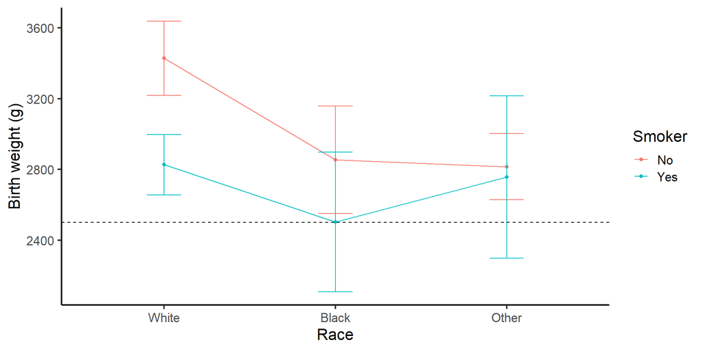

```r
ggplot(data = bwt_sum,
       aes(x = race,
           y = meanbwt,
           group = smoke,
           color = smoke)) +
  geom_point() +
  geom_path(aes(group = smoke)) +
  geom_errorbar(aes(ymin = meanbwt - 1.96*sdbwt/sqrt(nbwt),
                    ymax = meanbwt + 1.96*sdbwt/sqrt(nbwt)),
                width = 0.2) +
  labs(x = "Race",
       y = "Birth weight (g)") +
  scale_x_discrete(labels=c("1" = "White",
                            "2" = "Black",
                            "3" = "Other")) +
  scale_color_discrete(name = "Smoker",
                       labels = c("No", "Yes")) +
  geom_hline(yintercept = 2500, linetype = "dashed")
```

## 3.17 Check assumptions: Equal variance

- Graphically

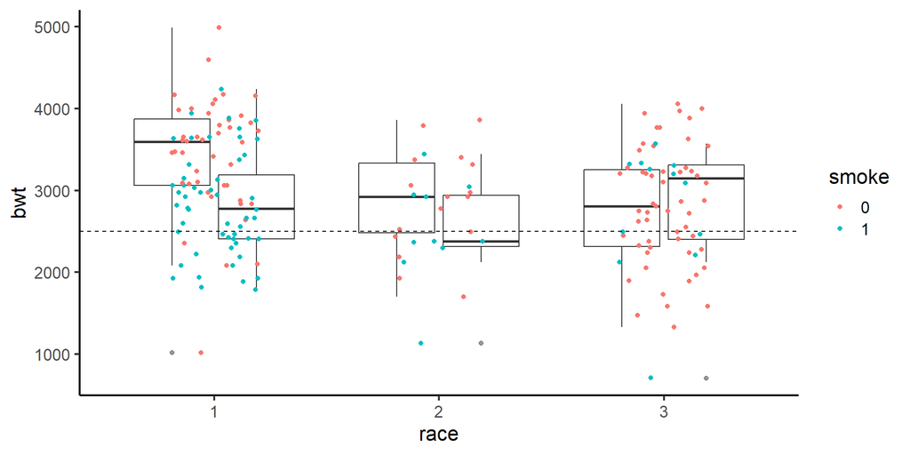

```r
ggplot(data = birthwt,
       aes(x = race,
           y = bwt,
           group = interaction(race, smoke))) +
  geom_boxplot(alpha = 0.5) +
  geom_jitter(width = 0.2, aes(color = smoke)) +
  geom_hline(yintercept = 2500, linetype = "dashed")
```

- `leveneTest()` in **car** package

```r
library(car)
leveneTest(bwt ~ race:smoke, data = birthwt)
```

```
Levene's Test for Homogeneity of Variance (center = median)
       Df F value Pr(>F)
group   5   0.345  0.885
      183
```

- $H_0$: No differences in variances across groups
  - NS result = equal variances

## 3.18 Example: ANOVA 1

```r
m1 <- lm(bwt ~ race + smoke + race*smoke,
         contrasts=list(race = contr.sum,
                        smoke = contr.sum),
         data = birthwt)
```

- `lm()` function for **linear model**
  - `outcome ~ predictors` format
  - Effects of `race`, `smoke`, and interaction (`race*smoke`)
  - Contrasts: Sum (`contr.sum`) in `list()` function to allow one for each factor

## 3.19 Example: ANOVA 2

- `Anova()` function in **car** package
  - Provide model (`m1` on last slide)
  - `type = 3` for correct type III sums of squares

```r
library(car)
Anova(m1, type = 3)
```

```
Anova Table (Type III tests)

Response: bwt
               Sum Sq  Df   F value                Pr(>F)
(Intercept) 965426089   1 2065.6367 < 0.00000000000000022 ***
race          5779165   2    6.1826              0.002522 **
smoke         3340683   1    7.1478              0.008185 **
race:smoke    2101808   2    2.2485              0.108463
Residuals    85529548 183
---
Signif. codes:  0 '***' 0.001 '**' 0.01 '*' 0.05 '.' 0.1 ' ' 1
```

## 3.20 Example: ANOVA 3

- We **reject** the null hypothesis that all `race` means are equal, F(2, 183) = 6.18, p = .0025. **At least one `race` group mean is different from the others.**
- We **reject** the null hypothesis that all `smoke` means are equal, F(1, 183) = 7.15, p = .0082. **At least one `smoke` group mean is different from the others.**
- We **retain** the null hypothesis that there is **not** an interaction, F(2, 183) = 2.25, p = .1085. **There is no interaction of `race` and `smoke`.**
  - The effect of `race` doesn’t depend on `smoke` and vice versa

## 3.21 Assumptions: Normality

- Graphically

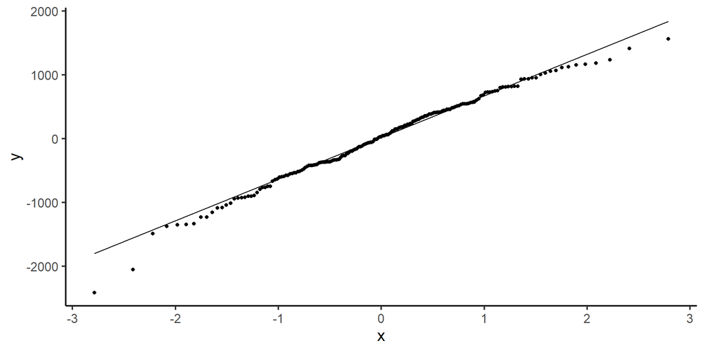

```r
m1resid <- data.frame(residuals(m1))
ggplot(data = m1resid,
       aes(sample = residuals.m1.)) +
  geom_qq() +
  geom_qq_line()
```

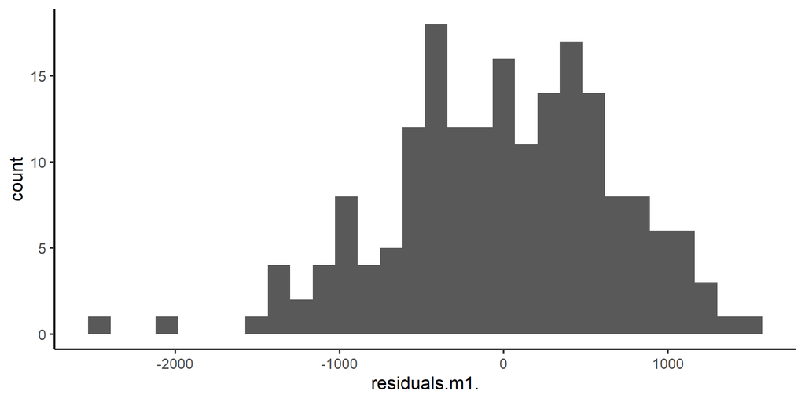

```r
m1resid <- data.frame(residuals(m1))
ggplot(data = m1resid,
       aes(x = residuals.m1.)) +
  geom_histogram()
```

- `shapiro.test()` in **stats**

```r
shapiro.test(resid(m1))
```

```
    Shapiro-Wilk normality test

data:  resid(m1)
W = 0.98836, p-value = 0.1246
```

- $H_0$: Observations come from normally distributed population
  - NS result = normally distributed residuals

## 3.22 `race`, `smoke`, no interaction

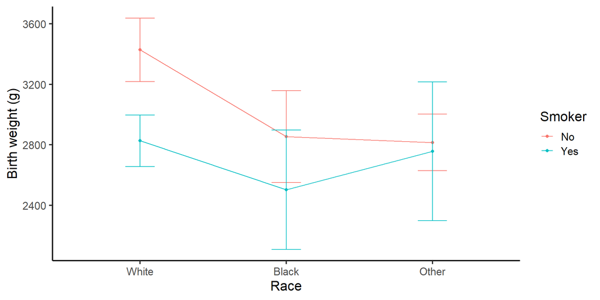

```r
ggplot(data = bwt_sum,
       aes(x = race,
           y = meanbwt,
           group = smoke,
           color = smoke)) +
  geom_point() +
  geom_path(aes(group = smoke)) +
  geom_errorbar(aes(ymin = meanbwt - 1.96*sdbwt/sqrt(nbwt),
                    ymax = meanbwt + 1.96*sdbwt/sqrt(nbwt)),
                width = 0.2) +
  labs(x = "Race",
       y = "Birth weight (g)") +
  scale_x_discrete(labels=c("1" = "White",
                            "2" = "Black",
                            "3" = "Other")) +
  scale_color_discrete(name = "Smoker",
                       labels = c("No", "Yes"))
```

## 3.23 Raw means

- `smoke` means

```r
birthwt %>% group_by(smoke) %>%
  summarize(meanbwt = mean(bwt))
```

```
# A tibble: 2 × 2
  smoke meanbwt
  <fct>   <dbl>
1 0       3056.
2 1       2772.
```

- `race` means

```r
birthwt %>% group_by(race) %>%
  summarize(meanbwt = mean(bwt))
```

```
# A tibble: 3 × 2
  race  meanbwt
  <fct>   <dbl>
1 1       3103.
2 2       2720.
3 3       2805.
```

## 3.24 Main effects vs simple effects

- Main effects
  - **Main effect** of factor A, *ignoring factor B*
    - e.g., Effect of `race`, ignoring `smoke`
  - **Any time there’s a significant main effect**
- Simple (main) effects
  - **Simple effect** of factor A (*at a level of factor B*)
    - e.g., Effect of `race` **for smokers** (i.e., `smoke` = 1)
  - **Only when you have a significant interaction**

## 3.25 Post hoc tests: emmeans

- `emmeans()` function in **emmeans** package
  - Provide model name (`m1`)
  - Type of contrast (`spec = trt.vs.ctrl`)
    - Other options: `pairwise`, `trt.vs.ctrlk` (last group = ctl)
  - Factor for contrasts: here, only `race`
  - Adjustment for multiple comparisons: here, `"none"`
    - Other options: `tukey`, `bonf`, `fdr`

## 3.26 Post hoc tests: emmeans

- Note that these are not the **raw means**
  - **Estimated marginal means** (emmeans): Model based

```r
library(emmeans)
emmeans(m1, spec = trt.vs.ctrl ~ race, adjust = "none")
```

```
$emmeans
 race emmean  SE  df lower.CL upper.CL
 1      3128  70 183     2990     3266
 2      2679 138 183     2407     2951
 3      2786 109 183     2572     3001

Results are averaged over the levels of: smoke
Confidence level used: 0.95

$contrasts
 contrast      estimate  SE  df t.ratio p.value
 race2 - race1     -449 155 183  -2.902  0.0042
 race3 - race1     -341 129 183  -2.636  0.0091

Results are averaged over the levels of: smoke
```

## 3.27 Caution re: causality

- Often, when you design an experiment that is analyzed via ANOVA, you’ve **randomized** people to groups
  - That allows for robust **causal inference**
    - Group differences are **causing** differences in the outcome
- People **aren’t** randomized to `race` or `smoke`
  - You **cannot** say that `race` is **causing** lower birth weight
  - It is *related to* or *associated with* lower birth weight

## 3.28 Limitations

- Only allows for **categorical** (grouping) predictors
  - If you have **continuous** predictors too, move to **regression models**
    - Linear (`lm()`), logistic, Poisson, gamma (`glm()`)
  - Example: Mother age, mother weight
- Using a regression approach also avoids dealing with ANOVA issues
  - Instead of contrasts, direct control over coding of predictors
    - Dummy codes

# 4 Within-subjects ANOVA

## 4.1 Within-subjects ANOVA

- Also called: repeated-measures ANOVA
- Extension of matched-pairs $t$-test to 3+ **related** groups
  - Typically repeated measures of the same unit
- No **between-groups** effects: **No groups**
  - Between-**subject** variance
  - Within-**subject** variance
  - Error variance

## 4.2 Limitations of WS ANOVA

- Doesn’t allow for **different #s of repeated measures**
  - Drop entire subject if even one is missing
- Often unrealistic assumptions
  - **Sphericity** / compound symmetry
  - Incorrect type I error, reduced power if not corrected
- Like other ANOVAs, don’t allow for continuous predictors
  - Continuous **time**

## 4.3 Advantages of RM designs

- In general, more **powerful** than between-subjects designs
  - Each person acts as their own control
- Can examine **change** in an individual over time
  - Longitudinal data

## 4.4 More extensions: Mixed ANOVA

- 1+ between-subjects factor **and** 1+ within-subjects factor
  - Group (BS) **and** time (WS)
- More complex, many of the same limitations of WS ANOVA
  - Assumption of sphericity
  - No continuous predictors
  - No different #s of repeated measures

## 4.5 More extensions: Mixed models

- Regression extension for repeated measures
  - Within-subject and between-subject predictors
  - Continuous and categorical predictors
  - Different # of repeated observations per unit
  - No unrealistic assumptions (i.e., sphericity)
- More complex
  - Need to understand regression, plus more unique complexities

# 5 In-class activities

## 5.1 In-class activities

- Do a factorial ANOVA
- Look at how you can do the ANOVA wrong
  - Type I SS (wrong) vs type III SS (correct)
- Play around a bit more with post hoc tests
  - Pairwise, treatment with last group as reference

## 5.2 Next week

- Discussion of special topics
  - 3 things that you found interesting and/or helpful about the topic
    - From the articles in the list or others you’ve found
    - Remember that you should use the listed readings and **at least 3 more** articles